# Results of Neural Network for *k* prediction

## 12/08/19

The following figures present the results of the training of the neural network for the prediction of Wear at the center. Those results are composed of three parts.

The first part, describes with text the data used for the prediction. Those data are split in eight categories, which are marked **True** if they have been used for prediction, **False** otherwise. Then are presented the results of the network over the datasets, and a specific example for a campaign. Finally, the following loading bars should not be taken into account for the results, they just correspond to Python loading the NN for following figures.

The second part shows figures of the dependency of the **k** parameter over the various input data. Each time, **k** is plotted depending on the value of one of the parameter, for each strip. Those graphs have been obtained from Dev and Test data, hence, some values can not represented in those datasets. *NB: **k** is presented as 'with Arbitrary Unit', however, it should be homogeneous to [m/t]*

The third part shows the same graphs as the second, but for the individual **Wear at the center** of each strip, plotted in µm. In the first version of the Neural Network, the wear is computed, for a strip $[i]$, as:

$W_c[i] = k[i] * (F/w * L)[i]$

All those graphs can serve as a base for future interpretations.

**Antonin Gay**

```
Mask data:
	F/w & L:			False
	F/w * L:			False
	Strip parameters:	True
	Roll parameters:	True
	Hardness Indicator:	False
	Strip Family:		True
	Roll Supplier:		True
	Campaign LineUp:	False
Training and testing results:
	MAE train: 42.6 (+/- 49.5) µm
	MAE dev: 42.5 (+/- 41.3) µm
	MAE test: 40.9 (+/- 29.6) µm
Example: Camp ID = 5 | Y_true = 460.1µm | Y_pred = 457.9µm)
```

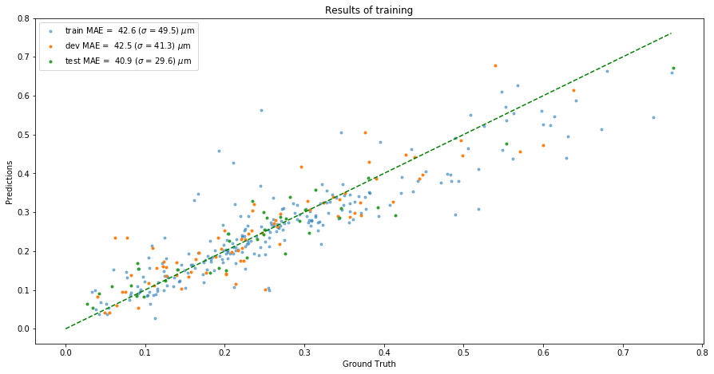

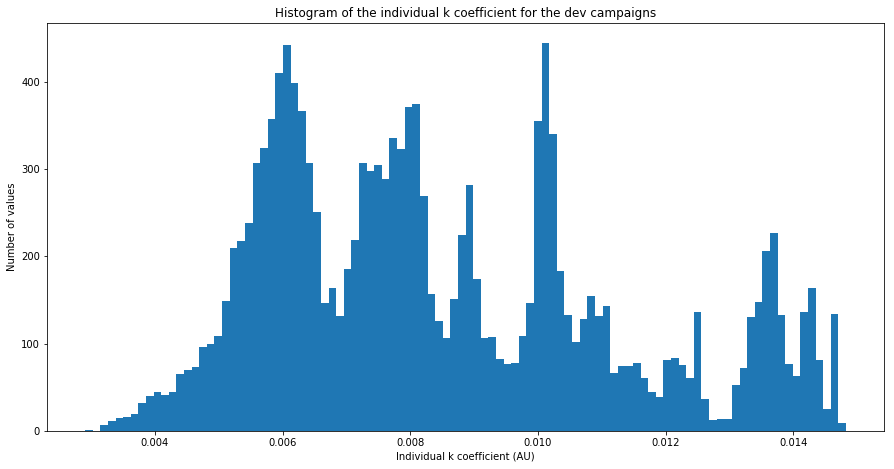

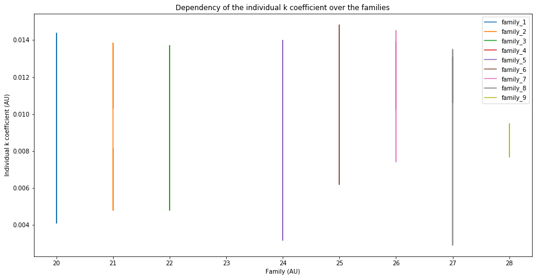

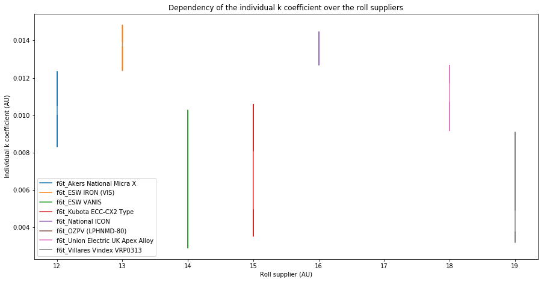

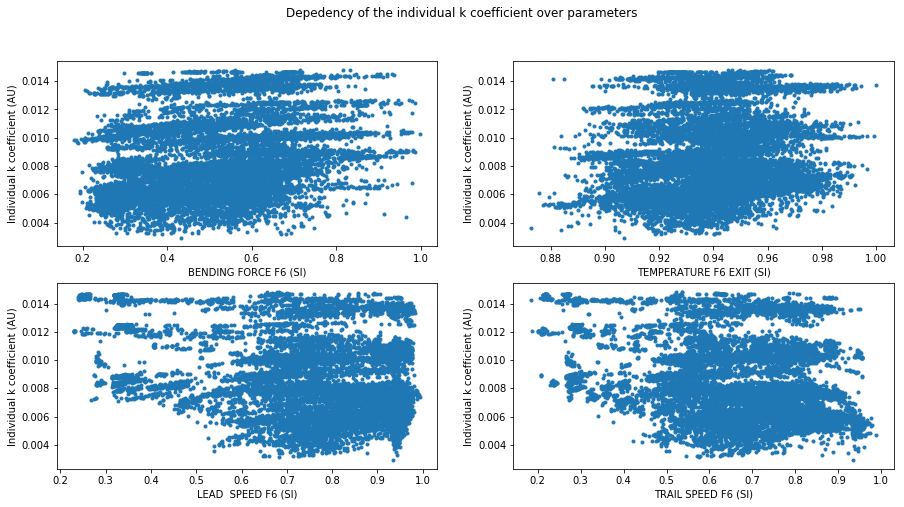

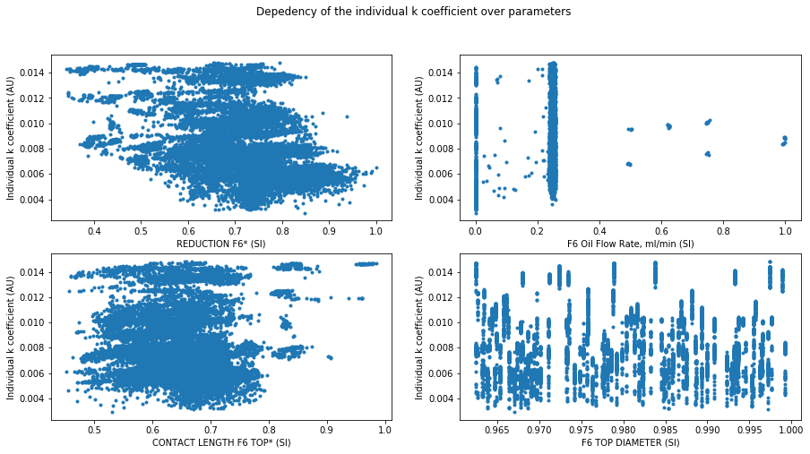

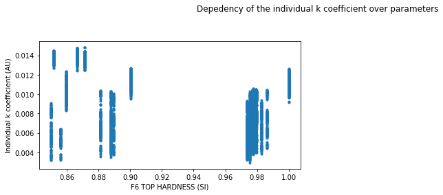

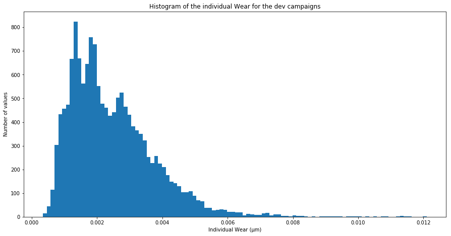

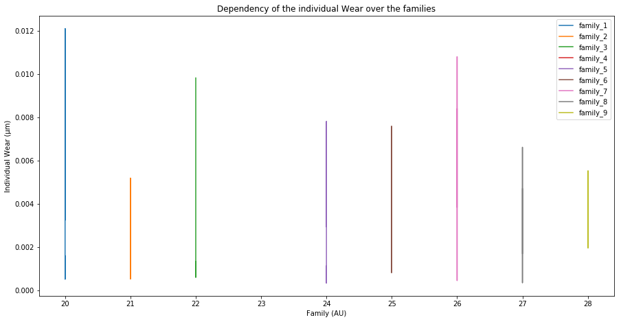

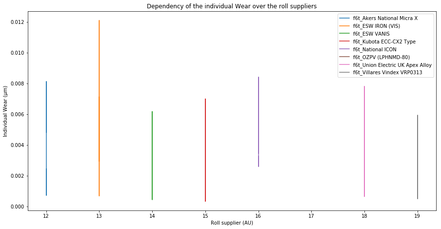

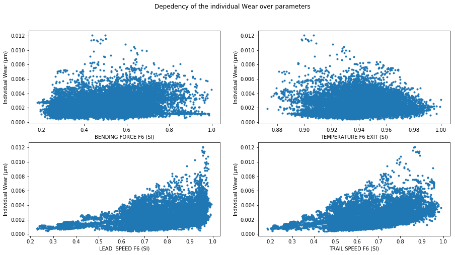

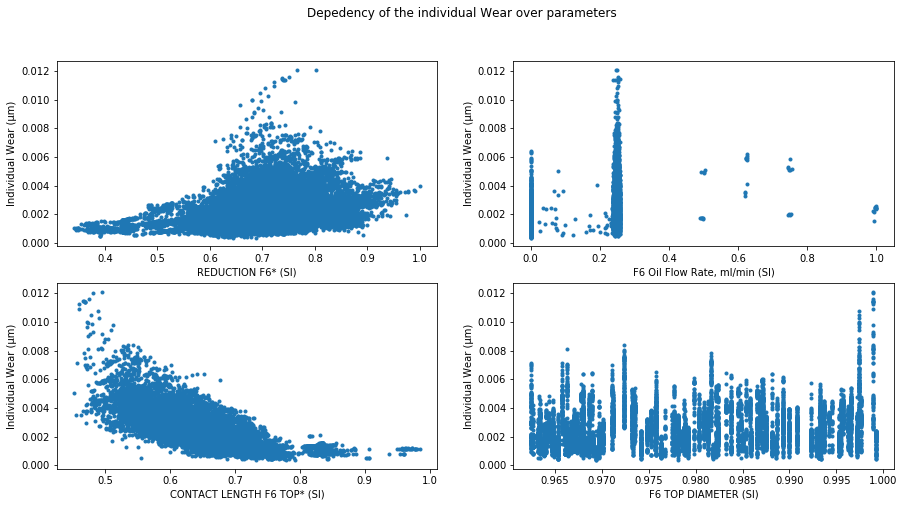

[1 more figures not shown]

```python
%matplotlib inline

import matplotlib.pyplot as plt
from Python_src.tests import test_plot_individual_pred

plt.rcParams['figure.figsize'] = [15, 7.5]

test_plot_individual_pred()
```